# Part 1: Analysis of DeFi TVL

In this project we are going to analyze some DeFi platforms. In particular we will focus on a metric, the *TVL (Total Value Locked)*, which is an index of the liquidity of a determined platform. According to the DYOR Crypto wiki it is defined as follows:

> TVL represents the amount of assets that are currently being staked in a specific protocol. This value is by no means meant to represent the amount of outstanding loans, but rather the total amount of underlying supply being secured by a specific application and/or by DeFi as a whole.

To begin our analysis, we need first of all to load some *libraries*:

```r
#Libraries for interactive and grid plots
library(gridExtra)
library(cowplot)

#Tidyverse
library(lubridate)
library(modelr)
library(tidyverse)

#Libraries for APIs calls
library(jsonlite)
library(httr)

#My pacakge, to install run: install_github("fradeca01/cryptoprice")
library(cryptoprice)
```

We download the dataset from [DeFi Llama](https://defillama.com/home) API. For each platform we get:

- the **TVL**
- in which blockchain it’s deployed
- generic datas

```r
#Get protocol list

#URL = "https://api.llama.fi/protocols"

#data = as_tibble(fromJSON(rawToChar(GET(URL)$content)))

#saveRDS(data, file="tvl.rds")

data = readRDS(file = "tvl(2021-06-12).rds") #We are using the data downloaded on 12 June 2021 and saved in a RDS file.

#Select only useful variables
data = select(data, id, name, symbol, chain, category, chains, tvl, chainTvls)

#We are working only with Dexes/Lending/Yield projects
data = filter(data, category == "Dexes" | category == "Lending" | category == "Yield")

#We are working only with projects running on Ethereum/Polygon or BSC
data = filter(data, chain=="Ethereum" | chain=="Binance" | chain=="Polygon" | chain=="Multi-Chain") %>%
  mutate(chainTvls = select(chainTvls, Ethereum, Binance, Polygon))

#Add variables to identify in wihch blockchain each protocol runs
data = data %>%
  mutate(Ethereum = unlist(map(chains, function(x) "Ethereum" %in% x)))%>%
  mutate(Binance = unlist(map(chains, function(x) "Binance" %in% x)))%>%
  mutate(Polygon = unlist(map(chains, function(x) "Polygon" %in% x)))

#Notice also that in some single chain platforms, like PancakeSwap, the chain Tvl is set to NA, let's fix that:
ids = data %>%
    filter(Binance == TRUE & is.na(chainTvls$Binance)) %>%
   pull(id)

data[data$id %in% ids,]$chainTvls$Binance = data[data$id %in% ids,]$tvl

ids = data %>%
    filter(Polygon == TRUE & is.na(chainTvls$Polygon)) %>%
   pull(id)

data[data$id %in% ids,]$chainTvls$Polygon = data[data$id %in% ids,]$tvl

ids = data %>%
    filter(Ethereum == TRUE & is.na(chainTvls$Ethereum)) %>%
   pull(id)

data[data$id %in% ids,]$chainTvls$Ethereum = data[data$id %in% ids,]$tvl
```

To begin let’s see which platforms (or protocol) have *higher TVL*, grouping them by *chain*.

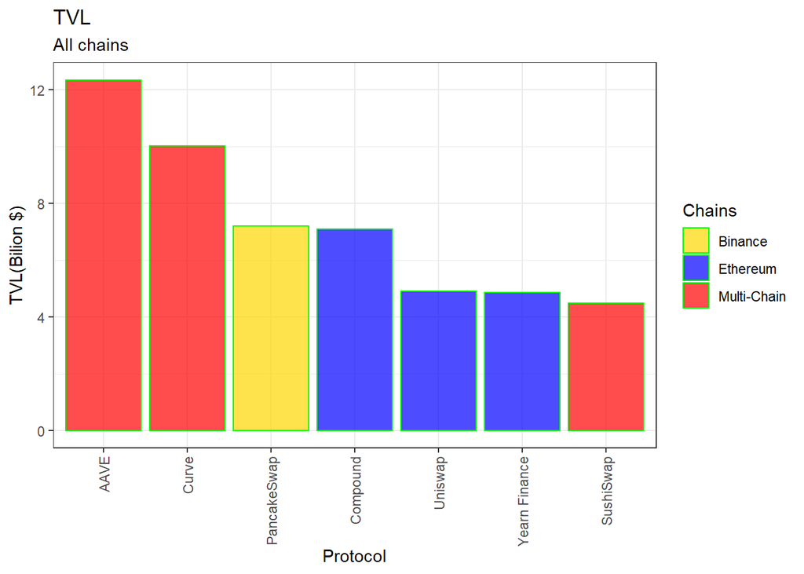

```r
plots = vector("list", 8)

#Plot best platforms grouping in chains:
plots[[1]] = data %>%
  arrange(desc(tvl))%>%
  head(7) %>%
  ggplot(aes(reorder(name ,-tvl), tvl/10^9)) +
    geom_bar(aes(fill = chain),
             orientation = "x",
             color = "green",
             stat = "identity",
             alpha = 0.7) +
    scale_fill_manual(values =c("Ethereum" = "blue", "Binance" = "gold", "Multi-Chain" = "red"))+
    labs(title = "TVL",
         subtitle = "All chains",
         fill = "Chains") +
    xlab("Protocol") +
    ylab("TVL(Bilion $)") +
    theme_bw()+
    theme(axis.text.x = element_text(angle = 90, vjust = 0.5, hjust=1)) #Rotate x labels

plots[[1]]
```

Now we check more in detail the TVL of different platforms for each chain:

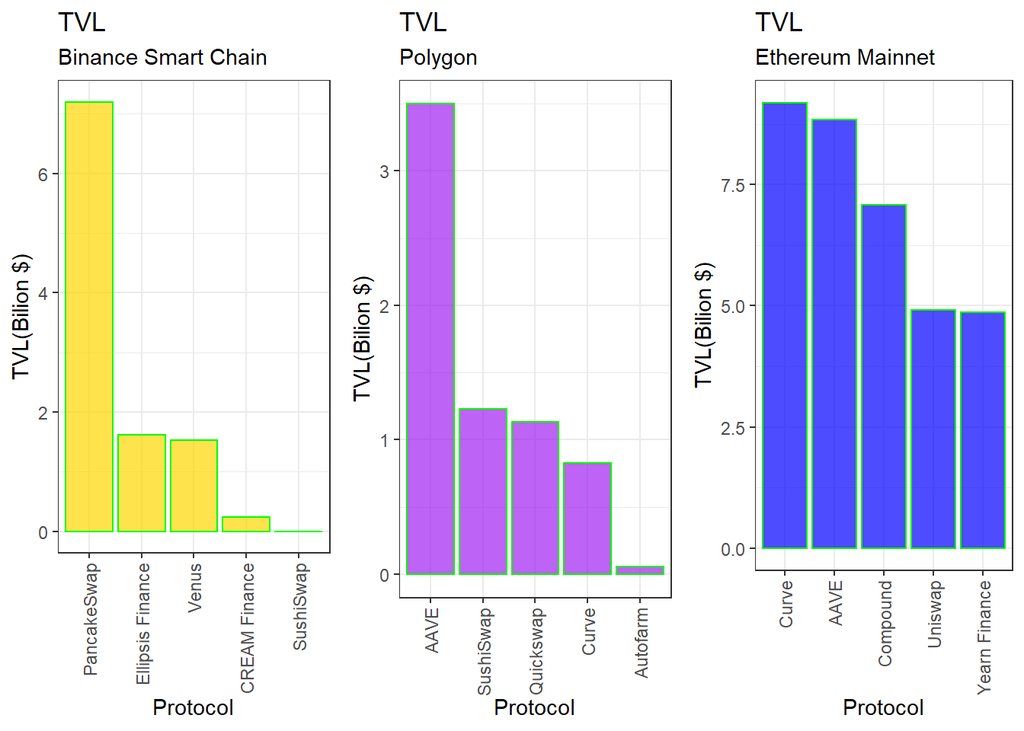

```r
#BSC
plots[[2]] = data %>%
  filter(Binance == TRUE) %>%
  arrange(desc(tvl)) %>%
  head(5) %>%
  ggplot() +
    geom_col(aes(reorder(name,-chainTvls$Binance),
                 y = chainTvls$Binance/10^9),
             fill = "gold",
             color="green",
             alpha = 0.7) +
    labs(title = "TVL", subtitle = "Binance Smart Chain") +
    xlab("Protocol") +
    ylab("TVL(Bilion $)") +
    theme_bw()+
    theme(axis.text.x = element_text(angle = 90, vjust = 0.5, hjust=1))

#Polygon
plots[[3]] = data %>%
  filter(Polygon == TRUE) %>%
  arrange(desc(tvl)) %>%
  head(5) %>%
  ggplot() +
    geom_col(aes(reorder(name,-chainTvls$Polygon),
                 y = chainTvls$Polygon/10^9),
             fill = "purple",
             color="green",
             alpha = 0.7) +
    labs(title = "TVL", subtitle = "Polygon") +
    xlab("Protocol") +
    ylab("TVL(Bilion $)") +
    theme_bw()+
    theme(axis.text.x = element_text(angle = 90, vjust = 0.5, hjust=1))

#Ethereum
plots[[4]] = data %>%
  filter(Ethereum == TRUE) %>%
  arrange(desc(tvl)) %>%
  head(5) %>%
  ggplot() +
    geom_col(aes(reorder(name,-chainTvls$Ethereum),
                 y = chainTvls$Ethereum/10^9), fill = "blue", color="green", alpha = 0.7) +
    labs(title = "TVL", subtitle = "Ethereum Mainnet") +
    xlab("Protocol") +
    ylab("TVL(Bilion $)") +
    theme_bw()+
    theme(axis.text.x = element_text(angle = 90, vjust = 0.5, hjust=1))

plot_grid(plots[[2]], plots[[3]], plots[[4]], ncol = 3)
```

Analyzing the plot we see that Ethereum is the blockchain where most platforms have locked tokens. On Binance Smart Chain that **PancakeSwap** is the only platform with a comparable *TVL*. *Polygon* is almost used by the same platforms as *Ethereum* (apart from **Quickswap**).

Now we analyze the evolution of the *TVL* over time, starting from the beginning of 2021, downloading the data from [Defi Llama](https://defillama.com/home) as before. For this purpose we begin analyzing the five platforms with higher capitalization:

1. AAVE
2. Curve
3. PancakeSwap
4. Compound
5. Uniswap

```r
BASE_URL = "https://api.llama.fi/protocol/"

#Get the names of the 5 most capitalized platforms.
top = head(arrange(data, desc(tvl)), 5)

protocolsNames = top$name

#Normalize the data to query the DefiLama API
protocolsNames = unlist(lapply(protocolsNames, function(x){
  gsub(" ", "-", x)
}))

#Get the number of platforms we are going to analyze
l = length(protocolsNames)

#Function which gets the history of the TVL of a given project.
historyTvl = function(protocolName){

  URL = paste(BASE_URL, protocolName ,sep="")

  res = rawToChar(GET(URL)$content)

  df = as_tibble(fromJSON(res)$tvl)

  df = mutate(df, date = as_date(as_datetime(date)))%>%
    filter(date > as_date("2021-01-01"))%>%
    mutate(totalLiquidityUSD = totalLiquidityUSD / 10^9)

  df
}

#Get the data-frames of the platforms
protocolsTvl = vector("list", l)

for (i in 1:l){
  protocolsTvl[[i]] = historyTvl(protocolsNames[i])
}

names(protocolsTvl) = protocolsNames

#Store the data-frames inside a tibble named "protocols"
protocols = tibble(name = protocolsNames, tvl = protocolsTvl)
```

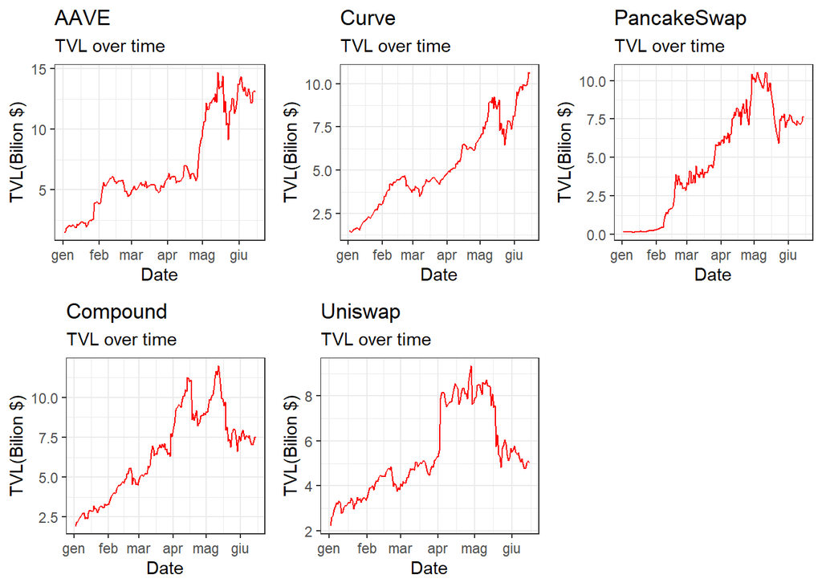

```r
 #Function which generates the plot
 genPlot1 = function(name){
   ggplot(protocols$tvl[[name]])+
     ggtitle(name) +
     geom_line(aes(date, totalLiquidityUSD), color = "red") +
     labs(subtitle = "TVL over time") +
     xlab("Date") +
     ylab("TVL(Bilion $)") +
     theme_bw()
 }

#Save the plots in protocols tibble
protocols = mutate(protocols, plot1 = map(name, genPlot1))

#Plot the plots in a grid
do.call("plot_grid", c(protocols$plot1, ncol=3))
```

Observing the plots, we notice that they follow a similar pattern: is the *TVL* affected by a common factor? To answer this question, we could try to compare the *TVL* with the price of *Ether(ETH)*, the token on which most of our platforms are based:

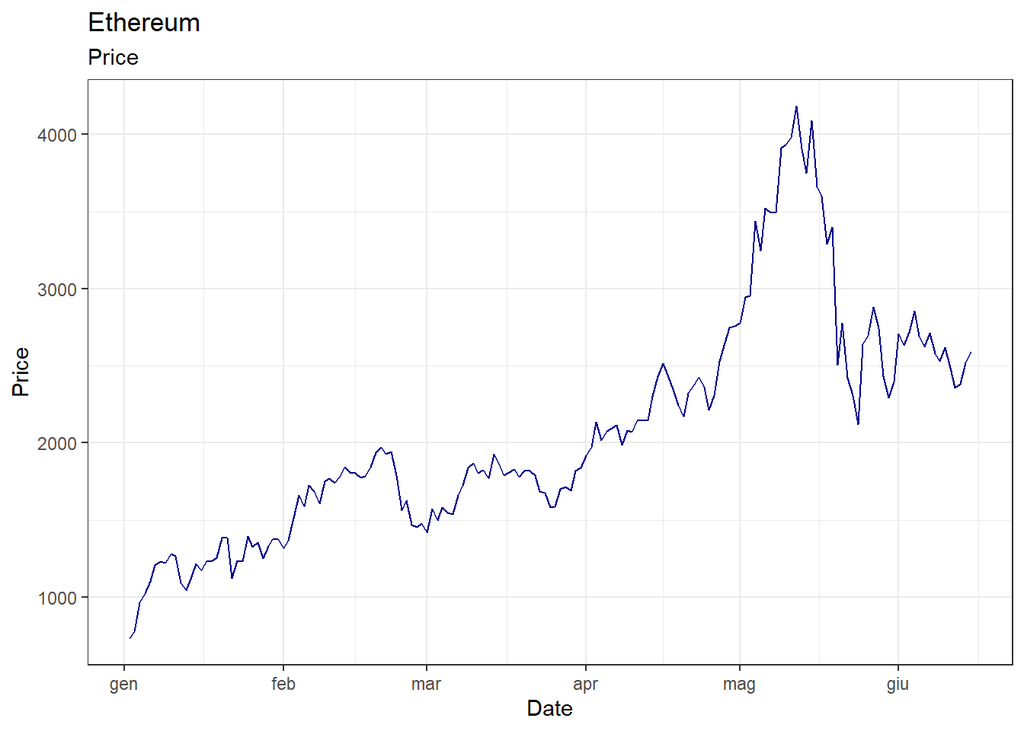

```r
ethId = get_token_id("eth")

ethPrice = get_token_price(ethId, 180, "daily") %>%
  select(date, price) %>%
  filter(date > "2021-01-01")

ggplot(ethPrice) +
  geom_line(aes(date, price), color="darkblue")+
     labs(title = "Ethereum", subtitle = "Price") +
     xlab("Date") +
     ylab("Price") +
     theme_bw()
```

To see if there is a correlation, let’s plot the *TVL* and the *ETH Price* in the same plot:

*Note: the price of ETH is re-scaled in each plot, so that it’s visible on top of the TVL plot*

> At [this link](https://fradeca01.shinyapps.io/InteractiveTVL/) you can find an interactive plot.

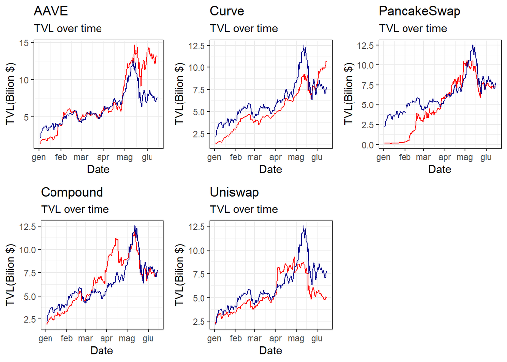

```r
#Inner join ETH price with TVLs tibbles
for(i in 1:l){
  protocols$tvl[[i]] = inner_join(protocols$tvl[[i]], ethPrice, by="date") %>%
     rename(ethPrice = price) %>%
     mutate(ethPrice = ethPrice*3/10^3) #Rescaline the price so it's visible in the plots
}

genPlot2 = function(name){
   ggplot(data = protocols$tvl[[name]])+
     ggtitle(name) +
     geom_line(aes(date, totalLiquidityUSD), color = "red") +
     labs(subtitle = "TVL over time") +
     xlab("Date") +
     ylab("TVL(Bilion $)") +
     geom_line(aes(date, ethPrice), color="darkBlue")+
     theme_bw()
 }

protocols = mutate(protocols, plot2 = map(name, genPlot2))

do.call("plot_grid", c(protocols$plot2, ncol=3))
```

From the plot above, the values seems correlated. Hence, we can try to make a scatter plot with *TVL* against *ETH Price*, where each point is representative of a different time:

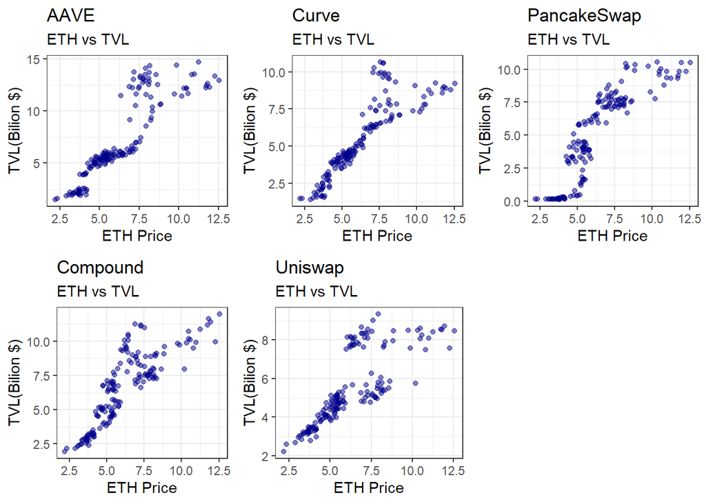

```r
genPlot3 = function(name){
  ggplot(data = protocols$tvl[[name]]) +
    geom_point(aes(ethPrice, totalLiquidityUSD), color="darkblue", alpha=0.5)+
    labs(title = name, subtitle = "ETH vs TVL") +
    xlab("ETH Price") +
    ylab("TVL(Bilion $)") +
    theme_bw()
}

protocols = mutate(protocols, plot3 = map(name, genPlot3))

do.call("plot_grid", c(protocols$plot3, ncol=3))
```

Now, we build a model for each platform, assuming a linear relation:

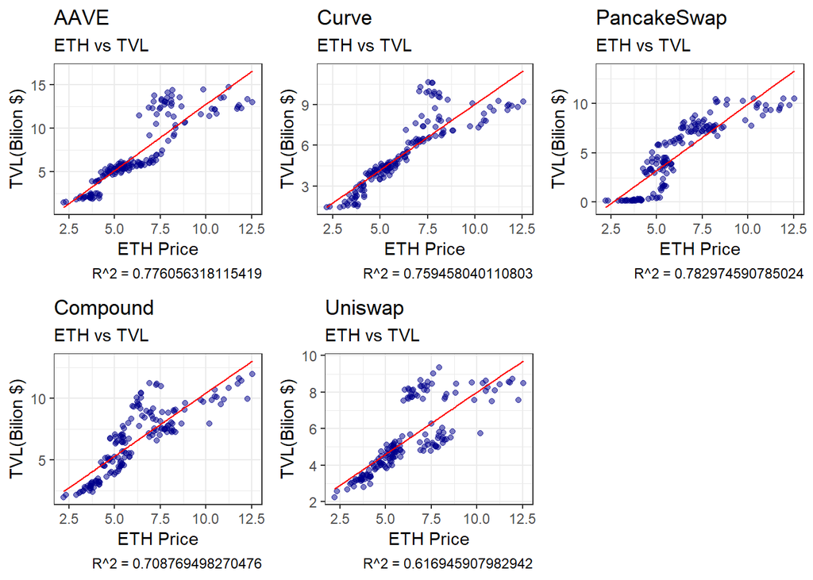

```r
#Function which builds the model
makeModel = function(x){
  lm(data = x, totalLiquidityUSD ~ ethPrice)
}

#Plug the model inside the tibble
protocols = mutate(protocols, model = map(tvl, makeModel))

#Store the p of the models in a list
r2 = vector("double", l)
for(i in 1:l){
   r2[[i]] = cor(protocols$tvl[[i]]$ethPrice, protocols$tvl[[i]]$totalLiquidityUSD)^2
}

names(r2) = protocolsNames

protocols = mutate(protocols, tvl = map2(tvl, model, add_predictions))

genPlot4 = function(name){
  ggplot(data = protocols$tvl[[name]]) +
    geom_point(aes(ethPrice, totalLiquidityUSD), color="darkblue", alpha=0.5)+
    geom_line(aes(ethPrice, pred), color="red")+
    labs(title = name, subtitle = "ETH vs TVL", caption=paste("R^2 =",r2[[name]])) +
    xlab("ETH Price") +
    ylab("TVL(Bilion $)") +
    theme_bw()
}

protocols = mutate(protocols, plot4= map(name, genPlot4))

protocols = mutate(protocols, r2 = r2)

do.call("plot_grid", c(protocols$plot4, ncol = 3))
```

```r
r2
```

```
##        AAVE       Curve PancakeSwap    Compound     Uniswap
##   0.7760563   0.7594580   0.7829746   0.7087695   0.6169459
```

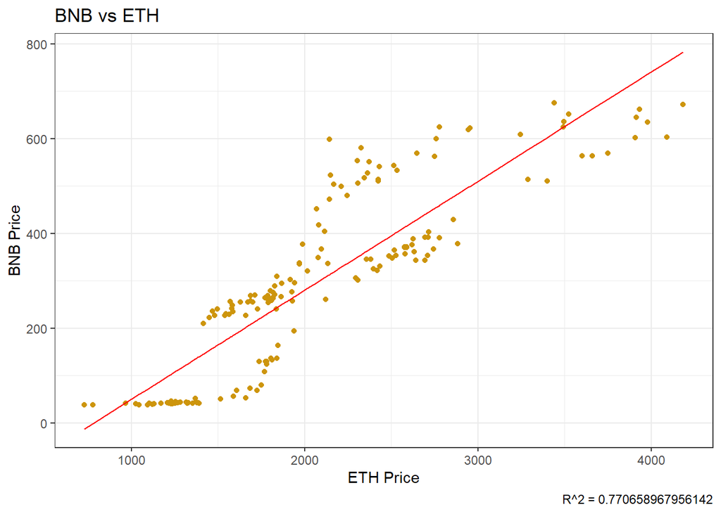

```r
bnbId = get_token_id("bnb")
bnbPrice = get_token_price(bnbId, 180, "daily") %>%
  select(date, price)

bnbvseth = inner_join(bnbPrice, ethPrice, by="date", suffix=c("Bnb", "Eth"))

# ggplot(bnbvseth)+
#   geom_point(aes(priceEth, priceBnb), color="blue")+
#   labs(title = "BNB vs ETH") +
#   xlab("ETH Price") +
#   ylab("BNB Price") +
#   theme_bw()

model = lm(data=bnbvseth, priceBnb ~ priceEth)
r2 = cor(bnbvseth$priceBnb, bnbvseth$priceEth)^2

bnbvseth = add_predictions(bnbvseth, model)

plots[[5]] = ggplot(bnbvseth)+
  geom_point(aes(priceEth, priceBnb), color="darkgoldenrod3")+
  geom_line(aes(priceEth, pred), color="red")+
  labs(title = "BNB vs ETH", caption=paste("R^2 =",r2)) +
  xlab("ETH Price") +
  ylab("BNB Price") +
  theme_bw()

plots[[5]]
```

```r
r2
```

```
## [1] 0.770659
```

The *ETH* and the *BNB* are indeed correlated, for completeness we will also do a model of **PancakeSwap** *TVL* with *BNB Price*:

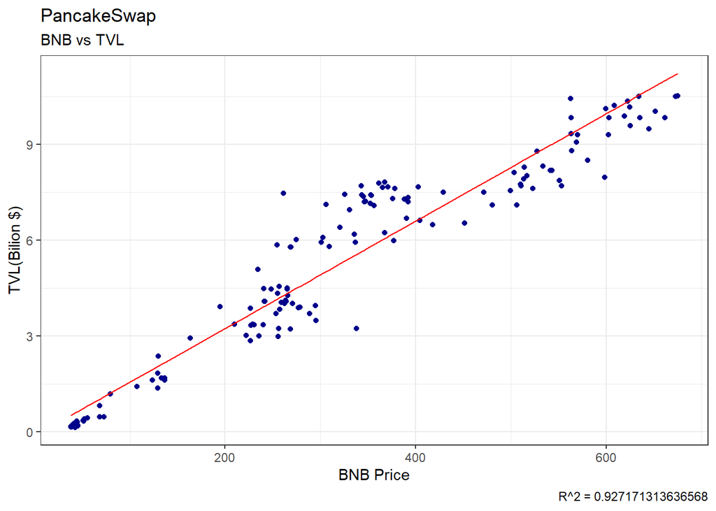

```r
pswap = protocols$tvl$PancakeSwap %>%
  select(date, totalLiquidityUSD)

pswap = inner_join(pswap, bnbPrice, by="date")%>%
  rename("bnbPrice" = "price")

mod2 = lm(data = pswap, totalLiquidityUSD ~ bnbPrice)

pswap = add_predictions(pswap, mod2)

r2 = cor(pswap$bnbPrice, pswap$totalLiquidityUSD)^2

plots[[6]] = ggplot(pswap)+
  geom_point(aes(bnbPrice, totalLiquidityUSD), color="darkblue")+
  geom_line(aes(bnbPrice, pred), color="red")+
  labs(title = "PancakeSwap", subtitle = "BNB vs TVL", caption = paste("R^2 =", r2)) +
  xlab("BNB Price") +
  ylab("TVL(Bilion $)") +
  theme_bw()

plots[[6]]
```

As we guessed **PancakeSwap** *TVL* is better correlated with *BNB*, indeed $p\approx0.96$.

We have learned that the *TVL in USD* of a *DeFi protocol* changes mainly because of the change in the value of the tokens deposited in the platform itself.

In any case, we can analyze the variation of the *TVL* expressed in *BNB* to see deposits and withdrawals of users. In the following plot we can see in **blue** the balance in *BNB* of PancakeSwap with respect to the expected value and in **red** the derivative, which represents the daily variation of the balance.

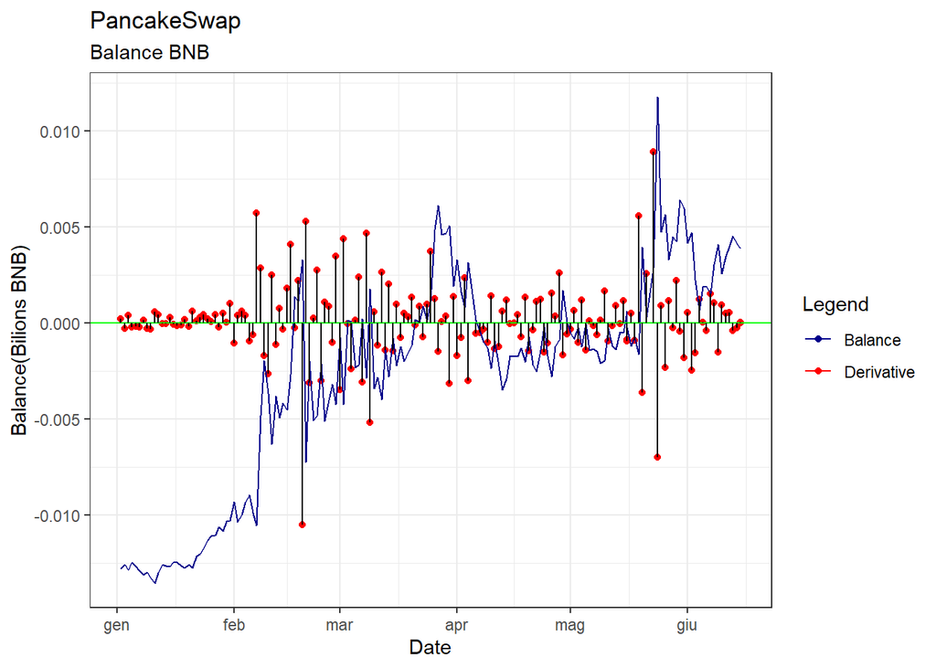

```r
coeff = mod2$coefficients[2]

pswap = pswap %>%
  mutate(totalLiquidityBNB = totalLiquidityUSD / bnbPrice) %>%
  mutate(resid = totalLiquidityBNB - coeff)

y = unlist(pswap$resid)
x = 1:length(y)

dy = vector(mode = "double", length = length(y))

for(i in x){
  if (i == length(y)){
    dy[i] = y[i] - y[i-1]
  } else {
    dy[i] = y[i+1] - y[i]
  }
}

pswap = mutate(pswap, derivative = dy)

plots[[7]] = pswap %>%
  ggplot()+
  geom_point(aes(date, derivative, color="Derivative")) +
  geom_line(aes(date, resid, color="Balance")) +
  geom_abline(intercept = 0, slope = 0, color="green")+
  geom_segment(aes(x = date, xend = date, y = 0, yend = derivative))+
  labs(title = "PancakeSwap",
       subtitle = "Balance BNB", color="Legend") +
  xlab("Date") +
  ylab("Balance(Bilions BNB)") +
  theme_bw()+
  scale_color_manual(values = c("Derivative" = "red", "Balance" = "darkblue"))

plots[[7]]
```

We can also compare the balance in *BNB* and the balance in *USD*:

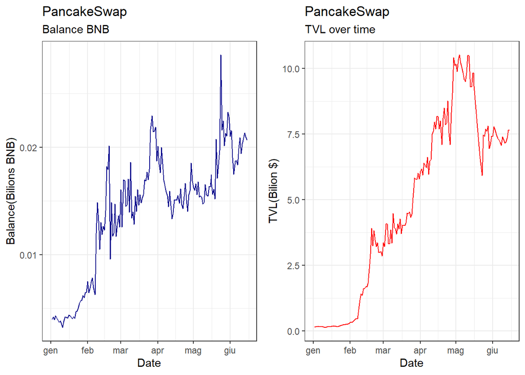

```r
plots[[8]] = pswap %>%
  ggplot()+
  geom_line(aes(date, totalLiquidityBNB), color="darkblue") +
  labs(title = "PancakeSwap",
       subtitle = "Balance BNB") +
  xlab("Date") +
  ylab("Balance(Bilions BNB)") +
  theme_bw()

plot_grid(plots[[8]], protocols$plot1[[3]])
```

With this last chunk we save the *protocols* data-frame and *plots* list, which contain the result of all our analysis, in a *.rds* file.

```r
protocols = protocols %>%
  select(name, tvl, plot1, plot2, plot3, plot4, model, r2)

saveRDS(protocols, file = "protocols.rds")
saveRDS(plots, file = "plots.rds")
```